# BIO 5700 Raster Exercise

Sarah Krueger

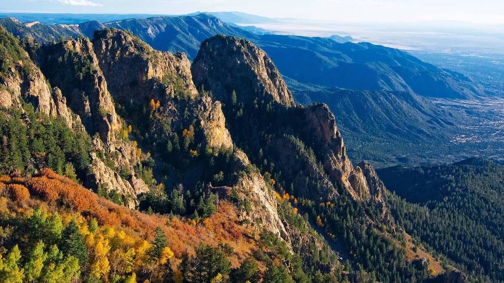

# 1 DEM Upload

I began by downloading a TIF file encompassing Albuquerque, New Mexico and surrounding cities around the Cibola National Forest.

I then used the ‘raster’ package to quickly plot the DEM TIF file.

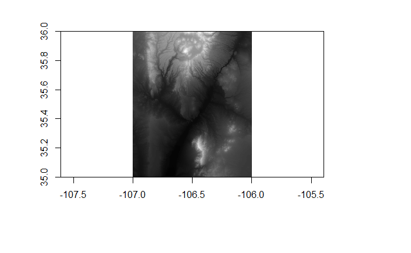

```r
dem <- raster('dem.tif')
plot(dem,col=grey(1:100/100),legend=F)
```

I also converted the DEM to a dataframe capable of being plotted in ggplot.

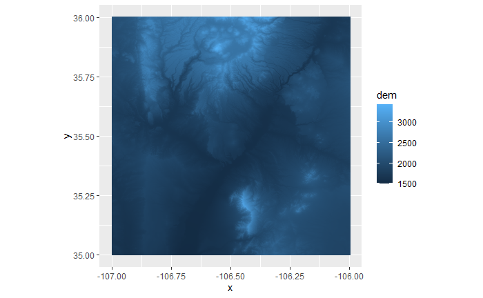

```r
dem_df <- data.frame(rasterToPoints(dem))
colnames(dem_df) <- c("x","y","dem")
ggplot(dem_df) + geom_raster(aes(x = x, y = y, fill = dem)) +coord_fixed()
```

I then created breaks on the DEM values to provide discrete values for display.

```r
breaks <- seq(min(dem_df$dem),max(dem_df$dem), length.out=100)
head(breaks)
```

```
[1] 1497.075 1516.629 1536.184 1555.739 1575.293 1594.848
```

Next, I created contour lines using the nlevels argument by setting the contour interval. Once the lines were created, fortify was used to create a dataframe and merge was used to connect the fortified dataset to the original elevation data.

```r
isolines <- rasterToContour(dem, nlevels = 20)
contours <- fortify(isolines)
z_values <- data.frame(rasterToContour(dem, nlevels = 20))
z_values$names <- rownames(z_values)
rownames(z_values) <- NULL
contour_lines <- merge(x = contours, y = z_values, by.x = "id", by.y = "names", all = TRUE)
head(contour_lines)
```

|  | id | long | lat | order | piece | group | level |
| --- | --- | --- | --- | --- | --- | --- | --- |
| 1 | C_1 | -106.9390 | 34.99992 | 1 | 1 | C_1.1 | 1600 |
| 2 | C_1 | -106.9366 | 35.00171 | 2 | 1 | C_1.1 | 1600 |
| 3 | C_1 | -106.9334 | 35.00307 | 3 | 1 | C_1.1 | 1600 |
| 4 | C_1 | -106.9302 | 35.00285 | 4 | 1 | C_1.1 | 1600 |
| 5 | C_1 | -106.9271 | 35.00228 | 5 | 1 | C_1.1 | 1600 |
| 6 | C_1 | -106.9252 | 34.99992 | 6 | 1 | C_1.1 | 1600 |

I then used ‘ggplot’ to display the DEM as well as the contours and utilize the breaks to display the color scheme.

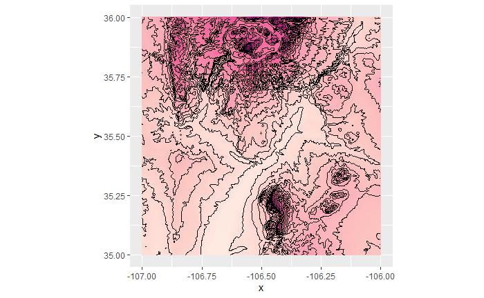

```r
ggplot() + geom_raster(data = dem_df, aes(x = x, y = y, fill = dem)) +
  scale_fill_gradientn(colours = c("#feebe2","#fcc5c0", "#fa9fb5","#f768a1", "#c51b8a", "#7a0177"), breaks = breaks, guide = "none") +
  geom_path(data = contour_lines, aes(x=long, y = lat, group = group), color = "black") +
  coord_fixed() + theme(legend.position = "bottom")
```

# 2 Hillshade

I created a slope and aspect dataset to create a hillshade and then set the sun angle to 50 and azimuth to 280 to create the hillshade image.

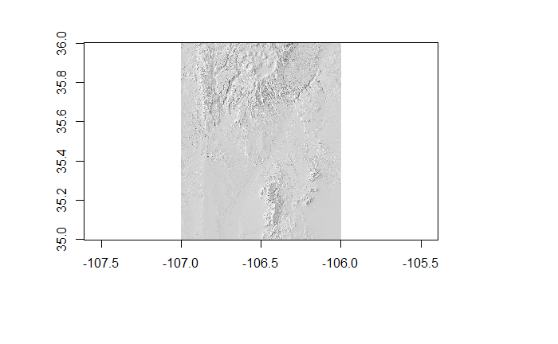

```r
slope <- terrain(dem, opt='slope')
aspect <- terrain(dem, opt='aspect')
hill <- hillShade(slope, aspect, 50, 280)
plot(hill, col=grey(0:100/100), legend=FALSE)
```

I then converted the hillshade to a dataframe suitable for use in ggplot.

```r
hill_df <- data.frame(rasterToPoints(hill))
```

# 3 Final Plot

Here is my final plot for the data.

[output not shown]

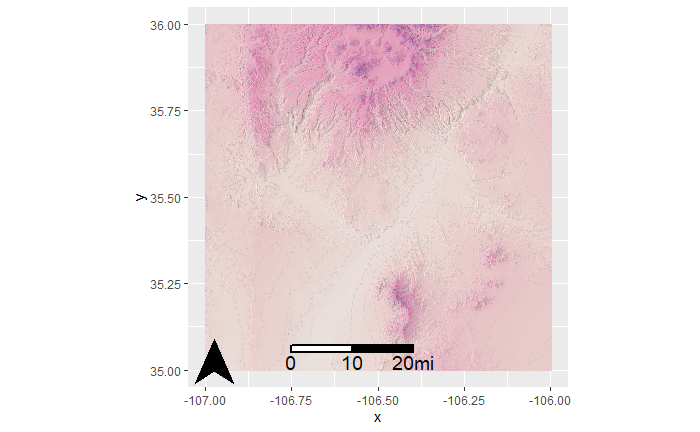

```r
ggplot() +
geom_raster(data = hill_df, aes(x = x, y = y, fill = layer)) +
  scale_fill_gradientn(colours = grey(1:100/100), guide = "none") +
  new_scale_fill() +
  geom_raster(data = dem_df, aes(x = x, y = y, fill = dem), alpha = 0.5) +
  scale_fill_gradientn(colours = c("#feebe2","#fcc5c0","#fa9fb5","#f768a1","#c51b8a","#7a0177"), breaks = breaks, guide = "none") +
  geom_path(data = contour_lines, aes(x=long, y = lat, group = group), color = "gray", alpha = 0.5, linetype = "dashed") +
  coord_fixed(xlim = c(-107,-106), ylim = c(35,36)) + theme(legend.position = "bottom") +
  north(dem_df, location = "bottomleft",scale = 0.009, symbol = 12, anchor = c(x= -106.9, y= 35.10)) +
  scalebar(contour_lines, dist = 10, dist_unit = "mi", transform = TRUE, location = "bottomleft", st.dist = 0.025, anchor = c(x=-106.75,y=35.05))
```

# 4 New Mexico Map

```r
siteOGR <- readOGR("C:/Users/skrueger/Desktop/Advanced Methods/Raster/Cibola.point.kml")
```

```r
nm_point <- as.data.frame(cbind(siteOGR@data,siteOGR@coords))

nm_point
```

| Name | Description | coords.x1 | coords.x2 | coords.x3 |
| --- | --- | --- | --- | --- |
| Cibola National Forest |  | -106.4746 | 35.20287 | 0 |

```r
nm_point[2] <- NULL
nm_point[4] <- NULL
colnames(nm_point) <- c("Name","X","Y")

leaflet(siteOGR) %>%
  addTiles() %>%
  addMarkers(popup = siteOGR@data$Name) %>%
  addCircleMarkers(popup = siteOGR@data$Name,
                   label = siteOGR@data$Description,
                   weight = 2,
                   color = "grey",
                   fillColor = "pink",
                   fillOpacity = 0.7)
```

[interactive chart not shown]

```r
NA
```